# meta-CART TRACE

Milou Sep

4/9/2021

# fix missing values

are there missing values?

```r
is.na(data.explore) %>% any()
```

```
## [1] TRUE
```

are there variables with > 1/3 missing?

```r
which(colSums(is.na(data.explore)) > (1/3)*nrow(data.explore)) # no values with 1/3 missing
```

```
## named integer(0)
```

check variable types

```r
str(data.explore) # all correct
```

```
## Classes 'escalc' and 'data.frame':   1647 obs. of  18 variables:
##  $ sample           : Factor w/ 7 levels "Mixed","Military",..: 3 3 3 3 3 3 3 3 3 3 ...
##  $ sex              : Factor w/ 3 levels "Female","Male",..: 2 2 2 2 2 2 2 2 2 2 ...
##  $ control.type     : Factor w/ 3 levels "Unexposed","Sham-exposed",..: 3 3 3 3 1 1 1 1 1 1 ...
##  $ ptsd.type        : Factor w/ 16 levels "Accident","Assault",..: 4 4 4 4 4 4 4 4 4 4 ...
##  $ population       : Factor w/ 16 levels "Albino Swiss (CD1)",..: 15 15 15 15 15 15 15 15 15 15 ...
##  $ measure          : Factor w/ 5 levels "exploration",..: 4 4 4 4 4 4 4 4 4 4 ...
##  $ time.since.trauma: num  30 30 30 30 NA NA NA NA NA NA ...
##  $ rhythm           : Factor w/ 3 levels "active","inactive",..: 1 1 1 1 1 1 1 1 1 1 ...
##  $ comparison       : Factor w/ 6 levels "A","B","C","D",..: 3 3 3 3 1 1 1 1 1 1 ...
##  $ new.idPTSD       : Factor w/ 408 levels "10066999.13",..: 398 398 398 398 400 400 400 400 400 400 ...
##  $ age              : Factor w/ 4 levels "(mature) adult",..: 2 2 2 2 2 2 2 2 2 2 ...
##  $ subject.cat      : Factor w/ 2 levels "Animal","Human": 2 2 2 2 2 2 2 2 2 2 ...
##  $ information.type : Factor w/ 10 levels "autobio","olfactory",..: 1 1 1 1 6 6 6 6 6 6 ...
##  $ phase            : Factor w/ 3 levels "Learning","Memory",..: 2 2 2 2 1 1 2 2 1 1 ...
##  $ valence          : Factor w/ 4 levels "Neutral","Emotional",..: 2 2 2 2 1 1 1 1 1 1 ...
##  $ cuectx           : Factor w/ 4 levels "Cue","Cue-Cue",..: 1 1 1 1 1 1 1 1 1 1 ...
##  $ yi               : num  -2 -4.56 0 -3.04 -0.36 ...
##   ..- attr(*, "ni")= num [1:18] 32 32 32 24 32 24 24 39 43 32 ...
##   ..- attr(*, "measure")= chr "SMD"
##  $ vi               : num  0.192 0.455 0.13 0.274 0.135 ...
##  - attr(*, "yi.names")= chr "yi"
##  - attr(*, "vi.names")= chr "vi"
##  - attr(*, "digits")= Named num [1:9] 4 4 4 4 4 4 4 4 4
##   ..- attr(*, "names")= chr [1:9] "est" "se" "test" "pval" ...
```

```r
#check missing values
summary(data.frame(data.explore)) # in sex and time pseudo
```

```
##               sample        sex               control.type      ptsd.type
##  Mixed           : 55   Female:  96   Unexposed     :845   SPS       :462
##  Military        : 10   Male  :1220   Sham-exposed  :407   FS        :299
##  Veteran         :216   Mixed : 324   Trauma-exposed:395   Deployment:266
##  Military+Veteran:  4   NA's  :   7                        Mixed     :227
##  Civilian        :273                                      PSS       :124
##  Rat             :915                                      RS        : 86
##  Mice            :174                                      (Other)   :183
##           population            measure    time.since.trauma      rhythm
##  Sprague-Dawley:680   exploration   :449   Min.   : 0.2500   active  :737
##  Civilian      :280   freezing      :634   1st Qu.: 0.8475   inactive:569
##  Veterans      :278   manipulation  :  6   Median : 2.1186   unknown :341
##  Wistar        :160   non-physiology:393   Mean   : 6.3510
##  C57BL/6       :137   physiology    :165   3rd Qu.: 5.0000
##  Lewis         : 30                        Max.   :55.0000
##  (Other)       : 82                        NA's   :139
##  comparison        new.idPTSD               age       subject.cat
##  A:237      12460691.54 :  26   (mature) adult: 223   Animal:1089
##  B:  5      12644351.355:  25   middle-aged   : 295   Human : 558
##  C:316      27686278.13 :  24   old adult     : 110
##  D:963      32302820.1  :  24   young adult   :1019
##  E: 47      15967648.52 :  18
##  F: 79      18313695.20 :  18
##             (Other)     :1512
##  information.type        phase          valence            cuectx
##  threat :937      Learning  :400   Neutral  :574   Cue        :909
##  verbal :236      Memory    :825   Emotional: 49   Cue-Cue    : 18
##  spatial:223      Extinction:422   Fear     :665   Cue-Context: 19
##  visual : 96                       Trauma   :359   Context    :701
##  safety : 81
##  autobio: 39
##  (Other): 35
##        yi                 vi
##  Min.   :-29.0425   Min.   : 0.008073
##  1st Qu.: -0.9564   1st Qu.: 0.122452
##  Median : -0.2607   Median : 0.210303
##  Mean   : -0.1745   Mean   : 0.409207
##  3rd Qu.:  0.5320   3rd Qu.: 0.357592
##  Max.   : 30.1581   Max.   :28.672211
##
```

```r
factors.to.fix <- c("sex"#, "sex.HC"
)
numeric.to.fix <- c("time.since.trauma")

for (i in c(1:length(numeric.to.fix))) {
  # i=1
  numeric.to.fix[[i]] -> varname
  data.explore[is.na(data.explore[,varname]),varname] <- median(unlist(data.explore[,varname]), na.rm = T)
}

#categorical missing: substitute with most common category  {from mAP}
categorical_mode <- function(x){
  names(table(x))[which.max(table(x))]
}


for (i in c(1:length(factors.to.fix))) {
  # i=1
  factors.to.fix[[i]] -> varname
  data.explore[is.na(data.explore[,varname]),varname] <- categorical_mode(unlist(data.explore[,varname]))
}

#any missing values left?
summary(data.frame(data.explore))
```

```
##               sample        sex               control.type      ptsd.type
##  Mixed           : 55   Female:  96   Unexposed     :845   SPS       :462
##  Military        : 10   Male  :1227   Sham-exposed  :407   FS        :299
##  Veteran         :216   Mixed : 324   Trauma-exposed:395   Deployment:266
##  Military+Veteran:  4                                      Mixed     :227
##  Civilian        :273                                      PSS       :124
##  Rat             :915                                      RS        : 86
##  Mice            :174                                      (Other)   :183
##           population            measure    time.since.trauma      rhythm
##  Sprague-Dawley:680   exploration   :449   Min.   : 0.2500   active  :737
##  Civilian      :280   freezing      :634   1st Qu.: 0.8475   inactive:569
##  Veterans      :278   manipulation  :  6   Median : 2.1186   unknown :341
##  Wistar        :160   non-physiology:393   Mean   : 5.9939
##  C57BL/6       :137   physiology    :165   3rd Qu.: 4.2308
##  Lewis         : 30                        Max.   :55.0000
##  (Other)       : 82
##  comparison        new.idPTSD               age       subject.cat
##  A:237      12460691.54 :  26   (mature) adult: 223   Animal:1089
##  B:  5      12644351.355:  25   middle-aged   : 295   Human : 558
##  C:316      27686278.13 :  24   old adult     : 110
##  D:963      32302820.1  :  24   young adult   :1019
##  E: 47      15967648.52 :  18
##  F: 79      18313695.20 :  18
##             (Other)     :1512
##  information.type        phase          valence            cuectx
##  threat :937      Learning  :400   Neutral  :574   Cue        :909
##  verbal :236      Memory    :825   Emotional: 49   Cue-Cue    : 18
##  spatial:223      Extinction:422   Fear     :665   Cue-Context: 19
##  visual : 96                       Trauma   :359   Context    :701
##  safety : 81
##  autobio: 39
##  (Other): 35
##        yi                 vi
##  Min.   :-29.0425   Min.   : 0.008073
##  1st Qu.: -0.9564   1st Qu.: 0.122452
##  Median : -0.2607   Median : 0.210303
##  Mean   : -0.1745   Mean   : 0.409207
##  3rd Qu.:  0.5320   3rd Qu.: 0.357592
##  Max.   : 30.1581   Max.   :28.672211
##
```

```r
any(is.na(data.explore)) # no
```

```
## [1] FALSE
```

## split data

Comparison B [B=non-exposed vs trauma exposed no PTSD (human)] is excluded from clinical data, as the experimental group does not contain PTSD patients. Note, this comparison is used in the sensitivity analysis of the theorydriven analysis. The comparison variable is also excluded from the human dataset, as the difference between comparison A [A= non-exposed vs trauma-exposed PTSD (human)] and comparison C [C=trauma-exposed (noPTSD) vs trauma-exposed PTSD (human)] is captured by the ‘control type’ variable (with levels unexposed, shamexposed, trauma exposed).

[A= non-exposed vs trauma-exposed PTSD (human); B=non-exposed vs trauma exposed no PTSD (human); C=trauma-exposed (noPTSD) vs trauma-exposed PTSD (human); D=non-exposed vs trauma-exposed (no PTSD checked) (animal); E=non-exposed vs trauma-exposed PTSD (animal); F=trauma-exposed (no ptsd) vs trauma-exposed PTSD (animal)]

```r
data.explore %>%
  filter(subject.cat == "Human") %>%
  filter(comparison != "B") %>%
  select(-c(rhythm, subject.cat, comparison)) %>%
  droplevels() ->clinical
str(clinical)
```

```
## Classes 'escalc' and 'data.frame':   553 obs. of  15 variables:
##  $ sample           : Factor w/ 5 levels "Mixed","Military",..: 3 3 3 3 3 3 3 3 3 3 ...
##  $ sex              : Factor w/ 3 levels "Female","Male",..: 2 2 2 2 2 2 2 2 2 2 ...
##  $ control.type     : Factor w/ 2 levels "Unexposed","Trauma-exposed": 2 2 2 2 1 1 1 1 1 1 ...
##  $ ptsd.type        : Factor w/ 10 levels "Accident","Assault",..: 4 4 4 4 4 4 4 4 4 4 ...
##  $ population       : Factor w/ 2 levels "Civilian","Veterans": 2 2 2 2 2 2 2 2 2 2 ...
##  $ measure          : Factor w/ 2 levels "non-physiology",..: 1 1 1 1 1 1 1 1 1 1 ...
##  $ time.since.trauma: num  30 30 30 30 2.12 ...
##  $ new.idPTSD       : Factor w/ 97 levels "10066999.13",..: 90 90 90 90 92 92 92 92 92 92 ...
##  $ age              : Factor w/ 3 levels "(mature) adult",..: 2 2 2 2 2 2 2 2 2 2 ...
##  $ information.type : Factor w/ 9 levels "autobio","safety",..: 1 1 1 1 5 5 5 5 5 5 ...
##  $ phase            : Factor w/ 3 levels "Learning","Memory",..: 2 2 2 2 1 1 2 2 1 1 ...
##  $ valence          : Factor w/ 4 levels "Neutral","Emotional",..: 2 2 2 2 1 1 1 1 1 1 ...
##  $ cuectx           : Factor w/ 4 levels "Cue","Cue-Cue",..: 1 1 1 1 1 1 1 1 1 1 ...
##  $ yi               : num  -2 -4.56 0 -3.04 -0.36 ...
##   ..- attr(*, "ni")= num [1:15] 32 32 32 24 32 24 24 32 24 43 ...
##   ..- attr(*, "measure")= chr "SMD"
##  $ vi               : num  0.192 0.455 0.13 0.274 0.135 ...
##  - attr(*, "yi.names")= chr "yi"
##  - attr(*, "vi.names")= chr "vi"
##  - attr(*, "digits")= Named num [1:9] 4 4 4 4 4 4 4 4 4
##   ..- attr(*, "names")= chr [1:9] "est" "se" "test" "pval" ...
```

Comparison is included in the preclinical dataset, as most datapoints come from comparison D and we want to explore the influence of this experimental variation.

D=non-exposed vs trauma-exposed (no PTSD checked) (animal); E=non-exposed vs trauma-exposed PTSD (animal); F=trauma-exposed (no ptsd) vs trauma-exposed PTSD (animal)]

```r
data.explore %>%
  filter(subject.cat == "Animal") %>%
  select(-subject.cat) %>%
  droplevels() ->preclinical
str(preclinical)
```

```
## Classes 'escalc' and 'data.frame':   1089 obs. of  17 variables:
##  $ sample           : Factor w/ 2 levels "Rat","Mice": 1 1 1 1 1 1 1 1 2 2 ...
##  $ sex              : Factor w/ 3 levels "Female","Male",..: 2 2 2 2 2 2 2 2 2 2 ...
##  $ control.type     : Factor w/ 3 levels "Unexposed","Sham-exposed",..: 2 2 2 2 2 2 2 1 2 2 ...
##  $ ptsd.type        : Factor w/ 7 levels "FS","Mixed","PSS",..: 7 7 7 1 1 1 1 6 1 1 ...
##  $ population       : Factor w/ 14 levels "Albino Swiss (CD1)",..: 12 12 12 14 14 14 14 12 3 3 ...
##  $ measure          : Factor w/ 3 levels "exploration",..: 1 1 1 1 1 1 1 2 2 2 ...
##  $ time.since.trauma: num  1.78 1.78 1.78 1.19 1.19 ...
##  $ rhythm           : Factor w/ 3 levels "active","inactive",..: 2 2 2 2 2 2 2 2 1 1 ...
##  $ comparison       : Factor w/ 3 levels "D","E","F": 1 1 1 1 1 1 1 1 1 1 ...
##  $ new.idPTSD       : Factor w/ 309 levels "12644351.355",..: 308 307 309 3 3 3 3 6 12 12 ...
##  $ age              : Factor w/ 2 levels "(mature) adult",..: 2 2 2 2 2 2 2 2 2 2 ...
##  $ information.type : Factor w/ 5 levels "olfactory","safety",..: 3 3 3 4 4 4 4 4 4 4 ...
##  $ phase            : Factor w/ 3 levels "Learning","Memory",..: 2 2 2 2 2 2 2 2 2 2 ...
##  $ valence          : Factor w/ 3 levels "Neutral","Fear",..: 1 3 3 3 3 3 3 2 3 3 ...
##  $ cuectx           : Factor w/ 3 levels "Cue","Cue-Context",..: 3 3 3 3 3 3 3 3 3 3 ...
##  $ yi               : num  -0.276 -1.693 -2.454 1.406 -1.093 ...
##   ..- attr(*, "ni")= num [1:17] 32 32 32 24 32 24 24 39 43 32 ...
##   ..- attr(*, "measure")= chr "SMD"
##  $ vi               : num  0.252 0.33 0.584 0.119 0.109 ...
##  - attr(*, "yi.names")= chr "yi"
##  - attr(*, "vi.names")= chr "vi"
##  - attr(*, "digits")= Named num [1:9] 4 4 4 4 4 4 4 4 4
##   ..- attr(*, "names")= chr [1:9] "est" "se" "test" "pval" ...
```

# metaCART: tree-model

- strength of the package metacart is that it can easily explore the interaction effects among multiple moderators using an interpretable tree model.
- multi-categorical variables, it creates automatically the contrasts between (combinations of) categories that account for the highest amount of heterogeneity.

from: 1. Li X, Dusseldorp E, Su X, Meulman JJ. Multiple moderator meta-analysis using the R-package Meta-CART. Behav Res Methods [Internet]. 2020;52(6):2657–73. Available from: http://dx.doi.org/10.3758/s13428-020-01360-0

- RE model
- c=0.5
- first fit without lookahead -> then recommended to use lookahead = T (especially in REmrt)
- maxL 10? geen advies, zelfde als hier: [1. Li X, Dusseldorp E, Su X, Meulman JJ. Multiple moderator meta-analysis using the R-package Meta-CART. Behav Res Methods. 2020;52(6):2657-2673. doi:10.3758/s13428-020-01360-0] ) ## Clinical

```r
readRDS( "processed_data/REtree.C.rds")->REtree.C
```

inspect warnings

```r
REtree.C$initial.tree
```

```
##            Qb      tau2
## 1    0.000000 1.1428857
## 2    5.636903 1.1455383
## 3  237.681512 0.7869333
## 4  276.986516 0.7611391
## 5  296.528711 0.7438629
## 6  312.413679 0.7302100
## 7  328.339308 0.7208354
## 8  343.703763 0.7094398
## 9  355.762821 0.7032998
## 10 366.585934 0.6999681
## 11 379.382039 0.6965316
##                                                                                      split
## 1                                                                                     <NA>
## 2                                                                        age = middle-aged
```

[output cut: 21 more lines]

NB eerste split is NA (ongeacht lookahead true or false), is hier ook: 1. Li X, Dusseldorp E, Su X, Meulman JJ. Multiple moderator meta-analysis using the R-package Meta-CART. Behav Res Methods. 2020;52(6):2657-2673. doi:10.3758/s13428-020-01360-0

```r
summary(REtree.C)
```

```
##
## Random Effects meta-tree (K = 553 studies);
## REmrt(formula = formula(c.vars.form), data = clinical, vi = vi,
##     c = 0.5, maxL = 10, xval = 10, lookahead = T)
##
## A tree with 7 terminal nodes was detected
## Moderators were detected as: age, sample, information.type, ptsd.type
##
## Test for Between-Subgroups Heterogeneity under RE assumption:
## Qb = 328.339 (df = 6), p-value < 1e-04;
## The estimate for the residual heterogeneity tau2 = 0.721;
##
## Subgroup Meta-analysis Results:
##      K      g    se    zval  pval  ci.lb  ci.ub
## 4    6 -5.991 0.359 -16.693 0.000 -6.695 -5.288 ***
## 6   36 -1.443 0.153  -9.418 0.000 -1.744 -1.143 ***
## 9   56 -0.090 0.122  -0.736 0.462 -0.329  0.149
## 10 219 -0.326 0.062  -5.270 0.000 -0.447 -0.205 ***
## 11  35  0.247 0.160   1.546 0.122 -0.066  0.561
## 12 167 -0.714 0.071 -10.106 0.000 -0.853 -0.576 ***
## 13  34 -0.116 0.155  -0.748 0.454 -0.419  0.187
## ---
## Signif. codes:  0 '***' 0.001 '**' 0.01 '*' 0.05 '.' 0.1 ' ' 1
```

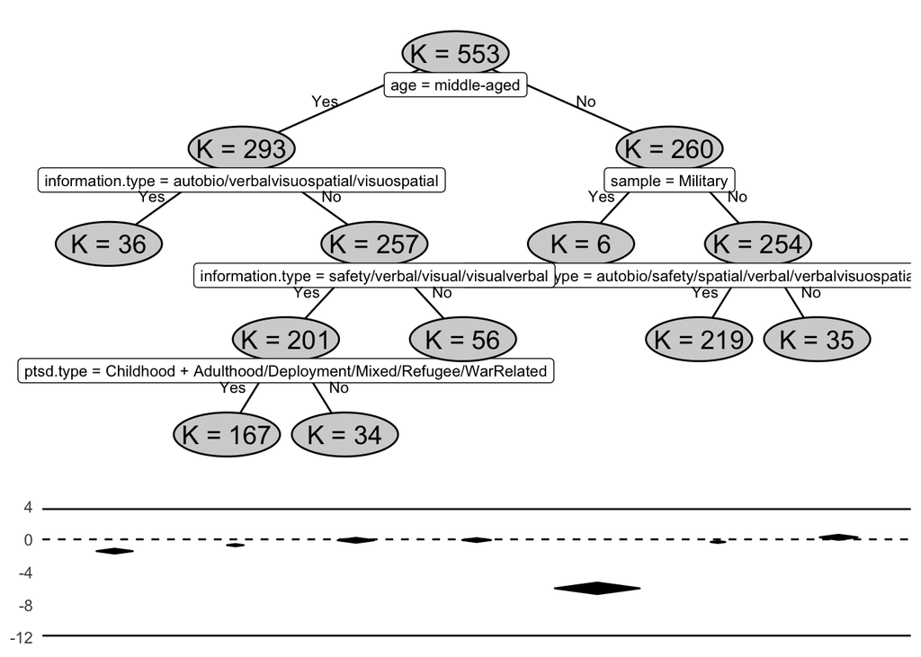

```r
plot(REtree.C)
```

```r
jpeg(file="results/metaCART.clinical.jpeg", height =3000, width = 3000, res=300, pointsize = 12)
plot(REtree.C)
dev.off()
```

## Preclinical

```r
readRDS("processed_data/REtree.P.rds")->REtree.P
```

inspect warnings

```r
REtree.P$initial.tree  # eerste split is NA
```

```
##           Qb      tau2
## 1     0.0000 1.8413828
## 2   291.7207 1.6081842
## 3  1290.0757 1.0477482
## 4  1483.8523 0.9772386
## 5  1563.8766 0.9520598
## 6  1658.6126 0.9166304
## 7  1791.8971 0.8890003
## 8  1872.7135 0.8592187
## 9  1960.2207 0.8248167
## 10 2029.6488 0.8019685
## 11 2093.6152 0.7900508
##                                                        split              mod
## 1                                                       <NA>             <NA>
## 2         information.type = spatial/safety/visual/olfactory information.type
```

[output cut: 21 more lines]

```r
summary(REtree.P)
```

```
##
## Random Effects meta-tree (K = 1089 studies);
## REmrt(formula = formula(p.vars.form), data = preclinical, vi = vi,
##     c = 0.5, maxL = 10, xval = 10, lookahead = T)
##
## A tree with 8 terminal nodes was detected
## Moderators were detected as: information.type, phase, ptsd.type, rhythm, population
##
## Test for Between-Subgroups Heterogeneity under RE assumption:
## Qb = 1872.713 (df = 7), p-value < 1e-04;
## The estimate for the residual heterogeneity tau2 = 0.859;
##
## Subgroup Meta-analysis Results:
##      K      g    se    zval  pval  ci.lb  ci.ub
## 4  341 -1.127 0.060 -18.829 0.000 -1.244 -1.010 ***
## 6  244  0.776 0.069  11.317 0.000  0.641  0.910 ***
## 9   61 -0.376 0.127  -2.950 0.003 -0.625 -0.126  **
## 11  90 -0.976 0.111  -8.755 0.000 -1.194 -0.757 ***
## 12  33 -4.519 0.245 -18.410 0.000 -5.000 -4.038 ***
## 13  60 -1.570 0.143 -10.970 0.000 -1.851 -1.290 ***
## 14  85  1.331 0.117  11.376 0.000  1.101  1.560 ***
## 15 175  2.377 0.089  26.759 0.000  2.203  2.551 ***
## ---
## Signif. codes:  0 '***' 0.001 '**' 0.01 '*' 0.05 '.' 0.1 ' ' 1
```

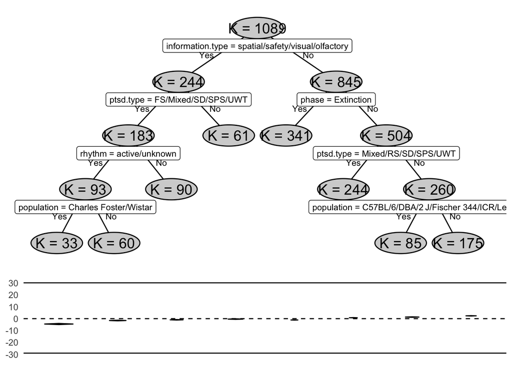

```r
plot(REtree.P)
```

```r
jpeg(file="results/metaCART.preclinical.jpeg", height = 3000, width = 3000, res=300, pointsize = 12)
plot(REtree.P)
dev.off()
```

# metaForest: random forest (= multiple trees)

```r
ModelInfo_mf()$notes # method from metaforest
```

```
## [1] "MetaForest does not use the train methods for classes 'formula' or 'recipe', because the variance of the effect size must be a column of the training data x. The name of this column is specified by providing the argument 'vi' when calling 'train'. To train a clustered MetaForest, simply prov…
```

## Clinical

```r
readRDS(file="processed_data/fitted.clinicalMetaForest.RDS")->cv.mf.cluster.clinical
```

### Tuning parameters

```r
cv.mf.cluster.clinical
```

```
## MetaForest
##
## 553 samples
##  14 predictor
##
## No pre-processing
## Resampling: Cross-Validated (10 fold)
## Summary of sample sizes: 494, 532, 468, 511, 533, 498, ...
## Resampling results across tuning parameters:
##
##   whichweights  mtry  min.node.size  RMSE      Rsquared    MAE
##   random        2     2              1.106874  0.06843100  0.7303745
##   random        2     4              1.098818  0.08441575  0.7217020
##   random        2     6              1.128512  0.06405359  0.7319555
##   random        4     2              1.157102  0.07776637  0.7630431
##   random        4     4              1.162559  0.06005012  0.7674034
##   random        4     6              1.131695  0.06691759  0.7357828
##   random        6     2              1.170906  0.06556019  0.7737703
##   random        6     4              1.133994  0.09981558  0.7418481
##   random        6     6              1.145812  0.08469458  0.7612053
##   fixed         2     2              1.078530  0.08920244  0.6933440
##   fixed         2     4              1.098878  0.08120908  0.7052381
##   fixed         2     6              1.077758  0.08086136  0.6945546
##   fixed         4     2              1.147663  0.08452852  0.7397742
##   fixed         4     4              1.136063  0.05944877  0.7255536
##   fixed         4     6              1.095739  0.05372742  0.7082614
##   fixed         6     2              1.130844  0.06837014  0.7248522
##   fixed         6     4              1.125356  0.08481342  0.7371688
##   fixed         6     6              1.154821  0.07654894  0.7472118
##   unif          2     2              1.134620  0.07488425  0.7484354
##   unif          2     4              1.135105  0.08091837  0.7383310
##   unif          2     6              1.133769  0.06680163  0.7450762
##   unif          4     2              1.143667  0.11278307  0.7387006
##   unif          4     4              1.190586  0.10222493  0.7666153
##   unif          4     6              1.113002  0.08179551  0.7355208
##   unif          6     2              1.186110  0.09807840  0.7808861
##   unif          6     4              1.202678  0.08829011  0.8031834
##   unif          6     6              1.197072  0.07282700  0.7981091
##
## RMSE was used to select the optimal model using the smallest value.
## The final values used for the model were whichweights = fixed, mtry = 2
##  and min.node.size = 6.
```

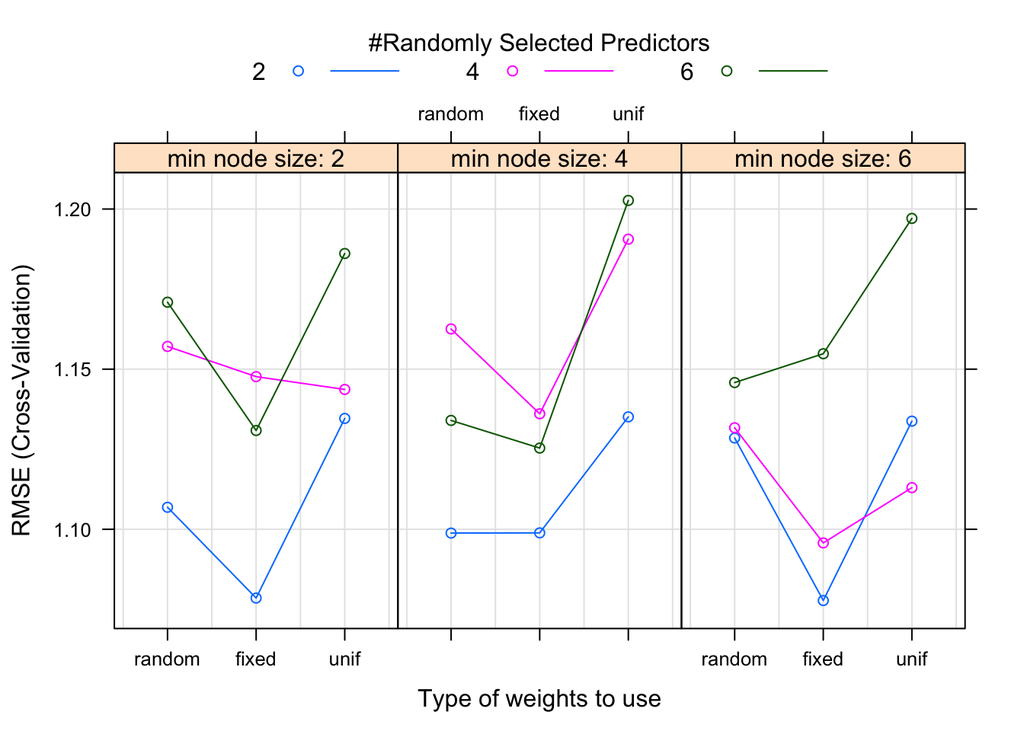

```r
plot(cv.mf.cluster.clinical) #
```

### Model convergence

```r
tiff(file="results/metaforest_Clinical_convergence.tiff", height=800, width=800, pointsize = 8, res=300)
plot(cv.mf.cluster.clinical$finalModel) + theme_pubr(base_size = 8)
dev.off()
```

### Model summary

```r
summary(cv.mf.cluster.clinical)
```

```
## MetaForest results
##
## Type of analysis:              Clustered MetaForest
## Number of studies:             Forest 1: 266, Forest 2: 287
## Number of moderators:          12
## Number of trees in forest:     Two forests of length 250
## Candidate variables per split: 2
## Minimum terminal node size:    6
## OOB prediction error (MSE):    1.5373
## R squared (OOB):               -0.0133
##
## Tests for Heterogeneity:
##                                tau2   tau2_SE I^2     H^2     Q-test    df
## Raw effect sizes:              1.3003 0.0853  93.4309 15.2229 7452.5461 552
## Residuals (after MetaForest):  1.3069 0.0857  93.4617 15.2946 7599.4444 552
##                                Q_p
## Raw effect sizes:              0.0000
## Residuals (after MetaForest):  0.0000
##
##
## Random intercept meta-analyses:
##                                Intercept se     ci.lb   ci.ub   p
## Raw effect sizes:              -0.5179   0.0507 -0.6172 -0.4186 0.0000
## Residuals (after MetaForest):  -0.0006   0.0508 -0.1001 0.0989  0.9906
```

### R(oob)

https://towardsdatascience.com/what-is-out-of-bag-oob-score-in-random-forest-a7fa23d710

Note, R(oob) also shown in summary above

### Cross validated R2 with SD

```r
cv.mf.cluster.clinical$results[which(cv.mf.cluster.clinical$results$whichweights == "fixed" &
                                       cv.mf.cluster.clinical$results$mtry == 2 &
                                       cv.mf.cluster.clinical$results$min.node.size == 6),] #details with the "best" model
```

```
##    whichweights mtry min.node.size     RMSE   Rsquared       MAE    RMSESD
## 12        fixed    2             6 1.077758 0.08086136 0.6945546 0.5013064
##    RsquaredSD     MAESD
## 12  0.1058582 0.2214198
```

### Variable importance

```r
VarImpPlot(cv.mf.cluster.clinical$finalModel) -> var.imp.plot.clinical

tiff(file="results/metaforest_Clinical_varImportance.tiff", height=1000, width=1000, pointsize=8, res=300)
var.imp.plot.clinical+  theme_pubr(base_size = 8)
# +  geom_hline(yintercept=11.5) +
#   annotate(geom="text", x=0.0017, y=12.5, label="Top 50%", color="darkblue")
dev.off()
```

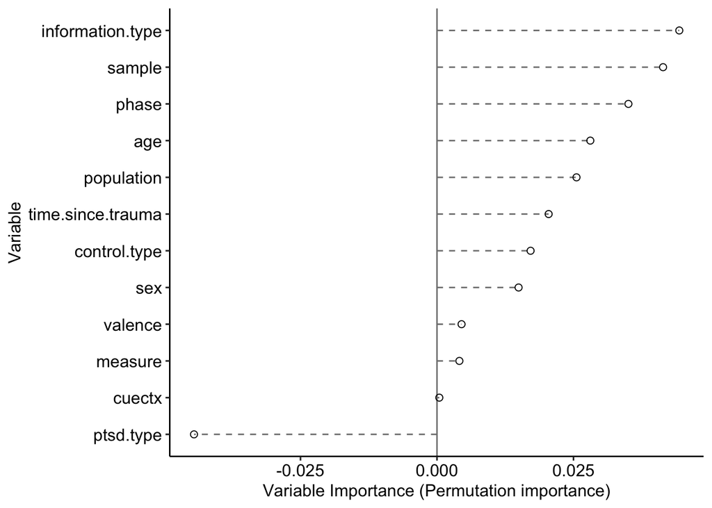

```r
var.imp.plot.clinical+  theme_pubr(base_size = 12)
```

negative variable importance (in metaforest) ~ just no relation to outcome http://developmentaldatascience.org/post/29-01-18_metaforest_no_effect/

### PD plots

```r
# https://www.rdocumentation.org/packages/metaforest/versions/0.1.3
varImp(cv.mf.cluster.clinical,scale = F) ->imp.scores.clinical


# export variable importance scores (ordered) to csv
imp.clinical <- as.data.frame(imp.scores.clinical$importance)
imp.clinical <- data.frame(overall = imp.clinical$Overall,
                           names   = rownames(imp.clinical))
write.csv2(imp.clinical[order(imp.clinical$overall,decreasing = T),],"results/important_variables_clinical_metaforest.csv")

# # select all variables
imp.clinical[order(imp.clinical$overall,decreasing = T),] -> important.vars.clinical
# slice_head(.,n=nrow(.) / 2)

# select top-3 most important variables
# top_n(imp.clinical,n=3, wt=overall)->important.vars.clinical

important.vars.clinical$names ->variable.clinical
variable.clinical
```

```
##  [1] "information.type"  "sample"            "phase"
##  [4] "age"               "population"        "time.since.trauma"
##  [7] "control.type"      "sex"               "valence"
## [10] "measure"           "cuectx"            "ptsd.type"
```

```r
# saveRDS(variable,"processed_data/important_variables.RDS")
```

#### Main PD plots

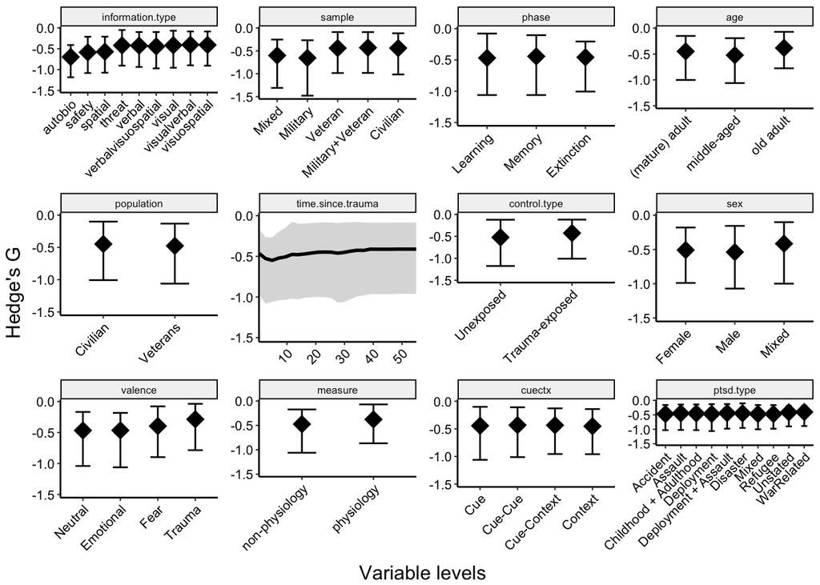

```r
# Create PD list
PartialDependence(cv.mf.cluster.clinical$finalModel, vars = variable.clinical, #moderator =  "phase",
                  bw=T,
                  rawdata=F, pi = .95,
                  output = 'list'
) ->PD.list.clinical

# change layout (for better read ability)
PD.list.clinical %>%
  map(~.x + labs(x=NULL, y=NULL)) %>%
  map(~.x + theme_pubr(base_size = 8)) %>%
  map(~.x + theme(axis.text.x = element_text(angle = 45,hjust = 1,vjust = 1))) %>%
  # map(~.x +  facet_grid(scales="free_y") ) %>% # not better
  map(ggplotGrob) ->grobz.clinical # remove y pabs


# PD.list.clinical %>%
#   map(~.x + theme(axis.text.x = element_text(angle = 20,hjust = 1,vjust = 1)))
# g <-
# do.call(gridExtra::gtable_rbind, grobz.clinical)->g

{
  # grobz.clinical <- lapply(PD.list.clinical, ggplotGrob) # https://stackoverflow.com/questions/35068129/arrange-ggplot-plots-grobs-with-same-widths-using-gtable-to-create-2x2-layout
  arrangeGrob(grobs=grobz.clinical,
              # heights = c(1,1,1,1#,
              #                # 1,1,1,1,
              #                # 1,1,1,1
              #                ),
              # aligned=T, # no effect
              # respect = F,
              ncol=4, #nrow=4,
              left="Hedge's G", bottom = "Variable levels")->PD.clinical # https://community.rstudio.com/t/common-axis-title-in-grid-arrange/96353/2
  grid.newpage()
  grid.draw(PD.clinical)
}
```

```r
# gtable_align(PD.clinical)

{jpeg(file="results/metaforest_PD_clinical.jpeg", height = 2000, width = 3000, res=300) # Higher quality output
  grid.draw(PD.clinical)
  dev.off()}
```

#### Clinical PD by phase

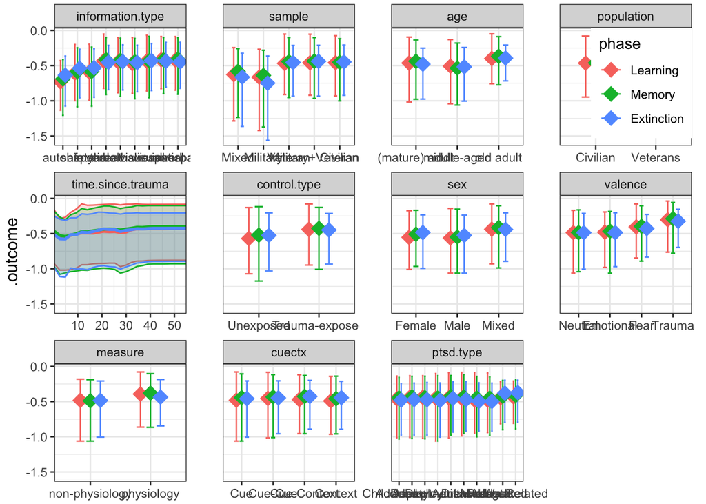

```r
# {jpeg(file="results/metaforest_PD_byPhase_clinical.jpeg", height = 1500, width = 5000, res=300) # Higher quality output
PartialDependence(cv.mf.cluster.clinical$finalModel, vars = variable.clinical, moderator =  "phase",rawdata=F, pi = .95)
```

```r
#scale_fill_viridis(discrete = TRUE, begin = 0.1, end = 0.9 , option = "cividis")
# dev.off()}
```

#### Clinical PD by valence

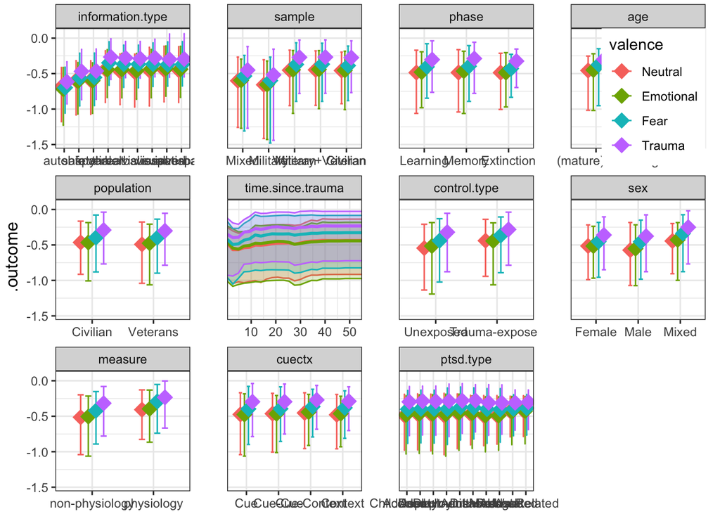

```r
# {jpeg(file="results/metaforest_PD_byValence_clinical.jpeg", height = 1500, width = 5000, res=300) # Higher quality output
PartialDependence(cv.mf.cluster.clinical$finalModel, vars = variable.clinical, moderator =  "valence",rawdata=F, pi = .95)
```

```r
# dev.off()}
```

Clinical weighted scatter

```r
# WeightedScatter(clinical, yi = "yi", vi = "vi", vars = variable.clinical, summarize = TRUE)
```

#### interactions from metaCART

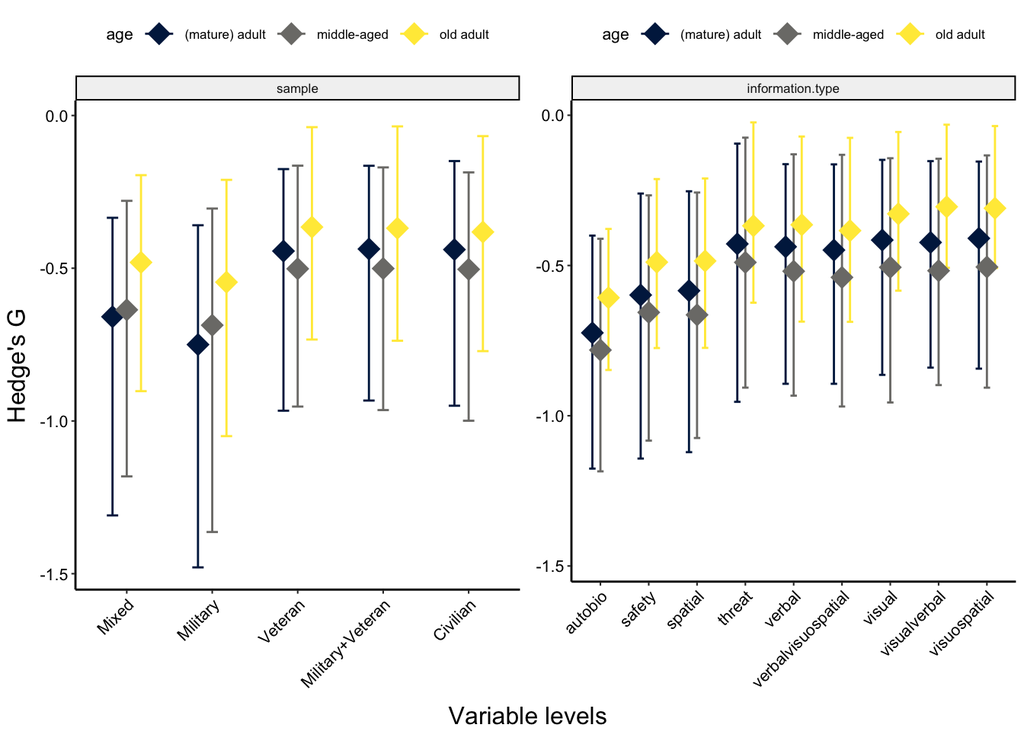

```r
PartialDependence(cv.mf.cluster.clinical$finalModel,
                  vars=c("sample", "information.type"), moderator = "age",
                  bw=F, rawdata=F, pi = .95, output = 'list')->PD.list.clinical.metacart

PD.list.clinical.metacart %>%
  map(~.x + labs(x=NULL, y=NULL)) %>%
  map(~.x + theme_pubr(base_size = 8)) %>%
  map(~.x + theme(axis.text.x = element_text(angle = 45,hjust = 1,vjust = 1))) %>%
   map(~.x + scale_color_viridis (discrete = TRUE, #begin = 0.1, end = 0.9 ,
                          option = "cividis") ) %>%
  map(ggplotGrob) ->grobz.clinical.metacart # remove y pabs

{arrangeGrob(grobs=grobz.clinical.metacart,
              ncol=2,
              left="Hedge's G", bottom = "Variable levels")->PD.clinical.metacart # https://community.rstudio.com/t/common-axis-title-in-grid-arrange/96353/2
  grid.newpage()
  grid.draw(PD.clinical.metacart)
}
```

```r
{jpeg(file="results/metaforest_PD_clinical_metaCARTfollowup.jpeg", height = 2000, width = 2500, res=300) # Higher quality output
# {jpeg(file="results/metaforest_PD_clinical.jpeg", height = 3000, width = 2000, res=300) # Higher quality output
  grid.draw(PD.clinical.metacart)
  dev.off()}
```

## Preclinical

```r
readRDS(file="processed_data/fitted.preclinicalMetaForest.RDS")->cv.mf.cluster.preclinical
```

### Tuning parameters

```r
cv.mf.cluster.preclinical
```

```
## MetaForest
##
## 1089 samples
##   16 predictor
##
## No pre-processing
## Resampling: Cross-Validated (10 fold)
## Summary of sample sizes: 962, 965, 1004, 1045, 995, 958, ...
## Resampling results across tuning parameters:
##
##   whichweights  mtry  min.node.size  RMSE      Rsquared   MAE
##   random        2     2              2.340561  0.4703574  1.242578
##   random        2     4              2.331258  0.4694464  1.249570
##   random        2     6              2.345285  0.4630355  1.259731
##   random        4     2              2.220580  0.5194160  1.235733
##   random        4     4              2.231987  0.5149329  1.223667
##   random        4     6              2.231837  0.5200172  1.219593
##   random        6     2              2.196012  0.5340829  1.229019
##   random        6     4              2.208763  0.5284847  1.238077
##   random        6     6              2.235340  0.5219511  1.227446
##   fixed         2     2              2.512487  0.4392241  1.292565
##   fixed         2     4              2.522017  0.4286987  1.306595
##   fixed         2     6              2.528965  0.4312560  1.305905
##   fixed         4     2              2.374283  0.4786971  1.215125
##   fixed         4     4              2.358699  0.4863228  1.212209
##   fixed         4     6              2.400960  0.4622234  1.239622
##   fixed         6     2              2.343797  0.4801121  1.218985
##   fixed         6     4              2.348950  0.4788747  1.216945
##   fixed         6     6              2.342253  0.4849665  1.213174
##   unif          2     2              2.317738  0.4692952  1.313590
##   unif          2     4              2.302372  0.4798745  1.293551
##   unif          2     6              2.296080  0.4834191  1.276594
##   unif          4     2              2.343477  0.4895586  1.338587
##   unif          4     4              2.317754  0.4918853  1.351367
##   unif          4     6              2.257059  0.5102333  1.276304
##   unif          6     2              2.320550  0.5038482  1.375811
##   unif          6     4              2.306755  0.5116086  1.322632
##   unif          6     6              2.260102  0.5246076  1.306481
##
## RMSE was used to select the optimal model using the smallest value.
## The final values used for the model were whichweights = random, mtry = 6
##  and min.node.size = 2.
```

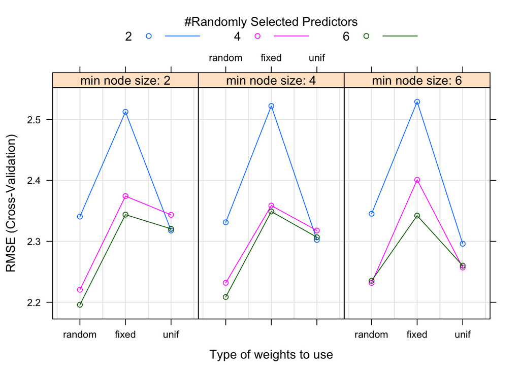

```r
plot(cv.mf.cluster.preclinical) #
```

### Model convergence

```r
tiff(file="results/metaforest_Preclinical_convergence.tiff", height=800, width=800, pointsize=8, res=300)
plot(cv.mf.cluster.preclinical$finalModel)+ theme_pubr(base_size = 8)
dev.off()
```

### Model summary

```r
summary(cv.mf.cluster.preclinical)
```

```
## MetaForest results
##
## Type of analysis:              Clustered MetaForest
## Number of studies:             Forest 1: 558, Forest 2: 531
## Number of moderators:          14
## Number of trees in forest:     Two forests of length 250
## Candidate variables per split: 6
## Minimum terminal node size:    2
## OOB prediction error (MSE):    7.1705
## R squared (OOB):               0.3373
##
## Tests for Heterogeneity:
##                                tau2   tau2_SE I^2     H^2     Q-test    df
## Raw effect sizes:              4.4260 0.2070  95.0184 20.0738 9721.6222 1088
## Residuals (after MetaForest):  1.8937 0.0966  89.0836 9.1606  8393.5415 1088
##                                Q_p
## Raw effect sizes:              0.0000
## Residuals (after MetaForest):  0.0000
##
##
## Random intercept meta-analyses:
##                                Intercept se     ci.lb   ci.ub   p
## Raw effect sizes:              -0.0053   0.0667 -0.1361 0.1256  0.9372
## Residuals (after MetaForest):  -0.1541   0.0458 -0.2438 -0.0644 0.0008
```

### R(oob)

https://towardsdatascience.com/what-is-out-of-bag-oob-score-in-random-forest-a7fa23d710

Note, R(oob) also shown in summary above

### Cross validated R2 with SD

```r
cv.mf.cluster.preclinical$results[which(cv.mf.cluster.preclinical$results$whichweights == "random" &
                                          cv.mf.cluster.preclinical$results$mtry == 6 &
                                          cv.mf.cluster.preclinical$results$min.node.size == 2),] #details with the "best" model
```

```
##   whichweights mtry min.node.size     RMSE  Rsquared      MAE    RMSESD
## 7       random    6             2 2.196012 0.5340829 1.229019 0.9801689
##   RsquaredSD     MAESD
## 7 0.09607656 0.2830034
```

### Variable importance

```r
VarImpPlot(cv.mf.cluster.preclinical$finalModel) ->var.imp.plot.preclinical

tiff(file="results/metaforest_Preclinical_varImportance.tiff", height=1000, width=1000, pointsize=8, res=300)
var.imp.plot.preclinical +  theme_pubr(base_size = 8)
dev.off()
```

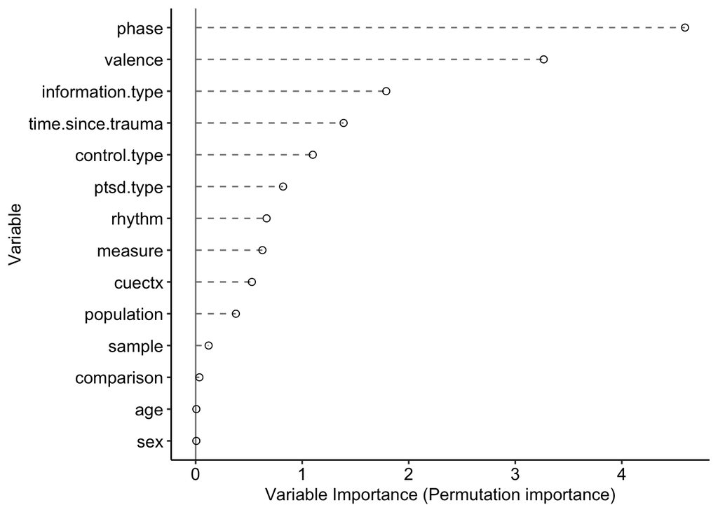

```r
var.imp.plot.preclinical +  theme_pubr(base_size = 12)
```

### PD plots

```r
# https://www.rdocumentation.org/packages/metaforest/versions/0.1.3
varImp(cv.mf.cluster.preclinical,scale = F) ->imp.scores.preclinical

# export variable importance scores (ordered) to csv
imp.preclinical <- as.data.frame(imp.scores.preclinical$importance)
imp.preclinical <- data.frame(overall = imp.preclinical$Overall,
                              names   = rownames(imp.preclinical))
write.csv2(imp.preclinical[order(imp.preclinical$overall,decreasing = T),],"results/important_variables_preclinical_metaforest.csv")

# select all variables
imp.preclinical[order(imp.preclinical$overall,decreasing = T),] -> important.vars.preclinical
# slice_head(.,n=nrow(.) / 2)

# select top-3 most important variables
# top_n(imp.preclinical,n=3, wt=overall)->important.vars.preclinical

important.vars.preclinical$names ->variable.preclinical
variable.preclinical
```

```
##  [1] "phase"             "valence"           "information.type"
##  [4] "time.since.trauma" "control.type"      "ptsd.type"
##  [7] "rhythm"            "measure"           "cuectx"
## [10] "population"        "sample"            "comparison"
## [13] "age"               "sex"
```

```r
# saveRDS(variable.preclinical,"processed_data/important_preclinical_variables.RDS")
```

#### Main PD plots

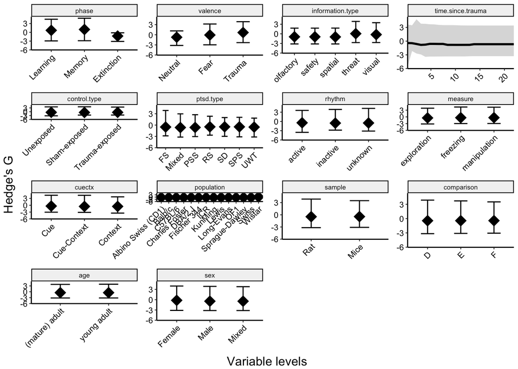

```r
PartialDependence(cv.mf.cluster.preclinical$finalModel, vars = variable.preclinical, bw=T, rawdata=F, pi = .95, output = 'list') ->PD.list.preclinical

# change layout  (for better read ability)
PD.list.preclinical %>%
  map(~.x + labs(x=NULL, y=NULL)) %>%
  map(~.x + theme_pubr(base_size = 8)) %>%
  map(~.x + theme(axis.text.x = element_text(angle = 45,hjust = 1,vjust = 1))) %>%
  map(ggplotGrob) ->grobz.preclinical # remove y pabs

{
  arrangeGrob(grobs=grobz.preclinical,
              ncol=4, #nrow=4,
              left="Hedge's G", bottom = "Variable levels")->PD.preclinical # https://community.rstudio.com/t/common-axis-title-in-grid-arrange/96353/2
  grid.newpage()
  grid.draw(PD.preclinical)
}
```

```r
{jpeg(file="results/metaforest_PD_preclinical.jpeg", height = 3000, width = 3000, res=300) # Higher quality output
  grid.draw(PD.preclinical)
  dev.off()}
```

#### Preclinical PD by phase

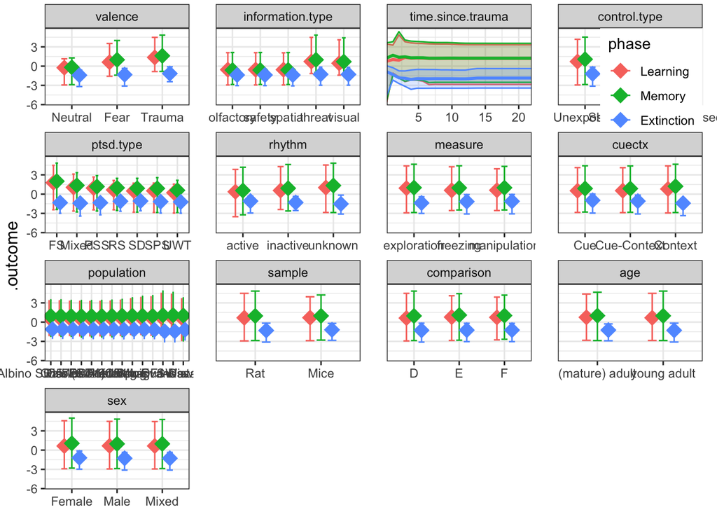

```r
# {jpeg(file="results/metaforest_PD_byPhase_preclinical.jpeg", height = 1500, width = 5000, res=300) # Higher quality output
PartialDependence(cv.mf.cluster.preclinical$finalModel, vars = variable.preclinical, moderator =  "phase",rawdata=F, pi = .95)
```

```r
# dev.off()}
```

#### Preclinical PD by valence

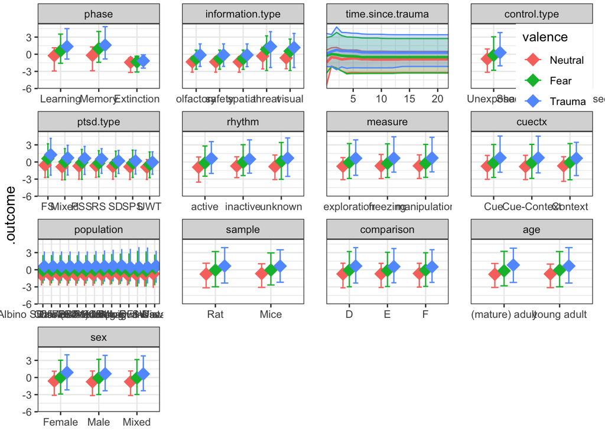

```r
# {jpeg(file="results/metaforest_PD_byValence_preclinical.jpeg", height = 1500, width = 5000, res=300) # Higher quality output
PartialDependence(cv.mf.cluster.preclinical$finalModel, vars = variable.preclinical, moderator =  "valence",rawdata=F, pi = .95)
```

```r
# dev.off()}
```

#### interactions from metaCART

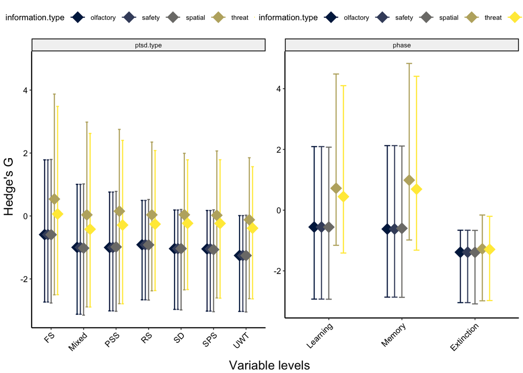

```r
PartialDependence(cv.mf.cluster.preclinical$finalModel,
                  vars=c("ptsd.type", "phase"), moderator = "information.type",
                  bw=F, rawdata=F, pi = .95, output = 'list')->PD.list.preclinical.metacart

PD.list.preclinical.metacart %>%
  map(~.x + labs(x=NULL, y=NULL)) %>%
  map(~.x + theme_pubr(base_size = 8)) %>%
  map(~.x + theme(axis.text.x = element_text(angle = 45,hjust = 1,vjust = 1))) %>%
     map(~.x + scale_color_viridis (discrete = TRUE, #begin = 0.1, end = 0.9 ,
                          option = "cividis") ) %>%
  map(ggplotGrob) ->grobz.preclinical.metacart # remove y pabs

{arrangeGrob(grobs=grobz.preclinical.metacart,
              ncol=2,
              left="Hedge's G", bottom = "Variable levels")->PD.preclinical.metacart # https://community.rstudio.com/t/common-axis-title-in-grid-arrange/96353/2
  grid.newpage()
  grid.draw(PD.preclinical.metacart)
}
```

```r
{jpeg(file="results/metaforest_PD_preclinical_metaCARTfollowup.jpeg", height = 2000, width = 2500, res=300) # Higher quality output
  grid.draw(PD.preclinical.metacart)
  dev.off()}
```

### Combine plots preclinical and clinical

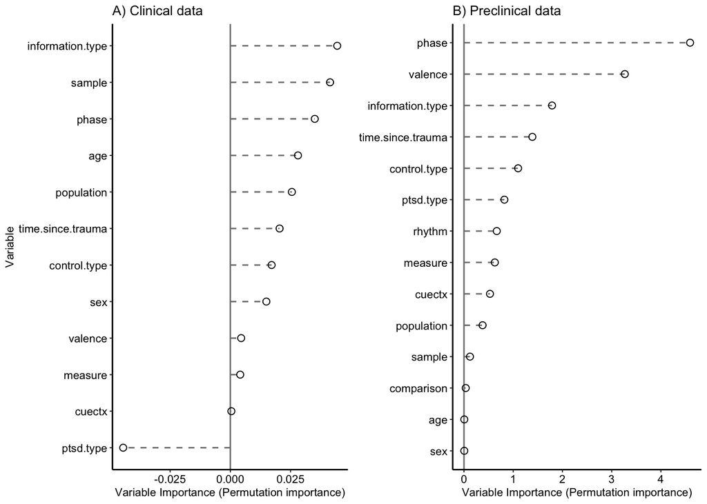

```r
ggarrange(
  var.imp.plot.clinical + labs(title = "A) Clinical data") + theme_pubr(base_size = 8),
  var.imp.plot.preclinical + labs(title = "B) Preclinical data") + theme_pubr(base_size = 8) + rremove("ylab"),
  # plot(REtree.C)+  theme_pubr(base_size = 12), # werkt niet
  ncol =2, nrow=1
) ->var.imp.plots

var.imp.plots
```

#### Save Var imp clinical and preclinical data together

```r
ggsave("results/VarImp.clinical.preclinical.tiff",
       plot=var.imp.plots,
       device="tiff", dpi = 300, height = 3, width = 7, limitsize = T )
```